# Analiza policijskih akcija na teritoriji grada Sijetla

Miloš Gravara

2024-06-06

### Skup podataka o policijskim akcijama na teritoriji grada Sijetla

Ovaj skup podataka sadrži informacije o pozivima policiji i odgovarajućim policijskim akcijama u Sijetlu. Kolone u skupu podataka su sledeće:

1. **CAD.Event.Number** - Jedinstveni identifikacioni broj događaja.
2. **Event.Clearance.Description** - Policijski kako je događaj završen.
3. **Call.Type** - Tip poziva sa 10 različitih vrednosti (911, Alarm, Onview…)
4. **Priority** - Prioritet poziva sa vrednostima od 1 (najmanjeg prioriteta) do 9 (najvišeg)
5. **Initial.Call.Type** - Prvobitna klasifikacija poziva od strane primaoca poziva u 911 centru, sa 325 različitih vrednosti
6. **Final.Call.Type** - Konačna klasifikacija poziva od strane policijskog službenika nakon pregleda, sa 431 različitom vrednošću
7. **Original.Time.Queued** - Vreme kada je poziv zabeležen
8. **Arrived.Time** - Vreme kada je policija stigla na lice mesta.
9. **Precinct** - Policijska stanica u Sijetlu
10. **Sector** - Policijski sektor
11. **Beat** - Teritorija i vreme tokom kojeg policijski službenih patrolira
12. **Blurred_Longitude** - Geografska dužina događaja
13. **Blurred_Latitude** - Geografska širina događaja

Skup podataka pruža detaljne informacije o svim pozivima koje je primila policija, uključujući tipove poziva, prioritete, vremena poziva i dolaska policije, kao i geografske lokacije događaja. Takođe uključuje početnu i konačnu klasifikaciju svakog poziva, što omogućava analizu kako se incidenti klasifikuju i rešavaju.

# Inicijalna priprema podataka

## Učitavanje i priprema neophodnih biblioteka

## Učitavanje podataka

- S obzirom na veličinu skupa podataka (1.1GB), podaci se učitavaju i dalje transformišu uz pomoć Apache Spark alata.
- Kako bi se učitali odgovarajući tipovi podataka, specificirana je šema spram koje alat spark učitava okvire podataka.

```r
schema <- list(
  CAD.Event.Number = "character",
  Event.Clearance.Description = "character",
  Call.Type = "character",
  Priority = "character",
  Initial.Call.Type = "character",
  Final.Call.Type = "character",
  Original.Time.Queued = "character",
  Arrived.Time = "character",
  Precinct = "character",
  Sector = "character",
  Beat = "character",
  Blurred_Longitude = "numeric",
  Blurred_Latitude = "numeric"
)

df <- spark_read_csv(sc, name = "police_calls", path = "Call_Data.csv", header = TRUE, columns = schema)
```

## Priprema podataka za analizu

- Kako bi se mogla vršiti adekvatna analiza podataka neophodno je uraditi nekoliko transformacija na početnom skupu podataka:

### Izbacivanje svih nepostojećih vrednosti iz skupa

```r
df_clean <- df %>% na.omit()
```

```
## * Dropped 535882 rows with 'na.omit' (5762484 => 5226602)
```

### Konverzija podataka u odgovarajući format

```r
df_clean <- df_clean %>%
  mutate(
    Original_Time_Queued = to_timestamp(Original_Time_Queued, "MM/dd/yyyy hh:mm:ss a"),
    Arrived_Time = to_timestamp(Arrived_Time, "MM/dd/yyyy hh:mm:ss a")
  )
```

### Filtriranje slučajeva kada je vreme dolaska policije pre vremena dešavanja incidenta

- Ovo je nemoguć slučaj

```r
df_clean <- df_clean %>%
  filter(!is.na(Original_Time_Queued) & !is.na(Arrived_Time) & Original_Time_Queued < Arrived_Time)
```

# Vizualizacija raspodele po pojedinačnim obeležjima i odnosa između obeležja

### Prikaz statističkih podataka o vremenima incidenata

```r
df_clean %>% summarise(
  min_original_time = min(Original_Time_Queued, na.rm = TRUE),
  max_original_time = max(Original_Time_Queued, na.rm = TRUE),
  min_arrived_time = min(Arrived_Time, na.rm = TRUE),
  max_arrived_time = max(Arrived_Time, na.rm = TRUE)
) %>% collect()
```

```
## # A tibble: 1 × 4
##   min_original_time   max_original_time   min_arrived_time
##   <dttm>              <dttm>              <dttm>
## 1 2009-06-02 03:35:46 2024-05-28 23:58:45 2009-06-02 04:01:55
## # ℹ 1 more variable: max_arrived_time <dttm>
```

### Vizualizacija raspodele po policijskim upravama:

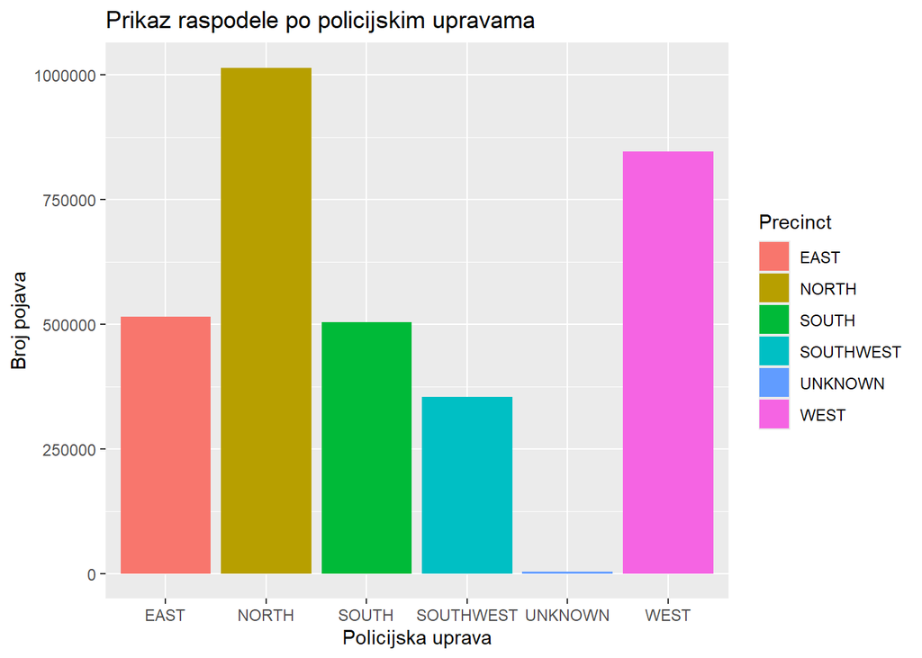

```r
precinct_counts <- df_clean %>%
  group_by(Precinct) %>%
  summarise(Count = n())

ggplot(precinct_counts, aes(x = Precinct, y = Count, fill = Precinct)) +
  geom_bar(stat = "identity") +
  labs(title = "Prikaz raspodele po policijskim upravama",
       x = "Policijska uprava",
       y = "Broj pojava",
       fill = "Precinct")
```

- Moze se primetiti da je najviše policijskih reakcija bilo u severnoj i zapadnoj policijskoj upravi.

### Vizualizacija raspodele po načinu razrešenja slučaja:

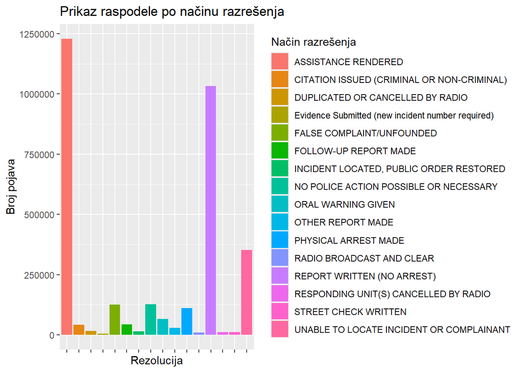

```r
clearence_counts <- df_clean %>%
  group_by(Event_Clearance_Description) %>%
  summarise(Count = n())

clearence_counts <- clearence_counts %>% filter(Count >= 5000)

ggplot(clearence_counts, aes(x = Event_Clearance_Description, y = Count, fill = Event_Clearance_Description)) +
  geom_bar(stat = "identity") +
  labs(title = "Prikaz raspodele po načinu razrešenja",
       x = "Rezolucija",
       y = "Broj pojava",
       fill = "Način razrešenja") +
  theme(axis.text.x = element_blank())
```

### Vizualizacija raspodele prema prioritetu

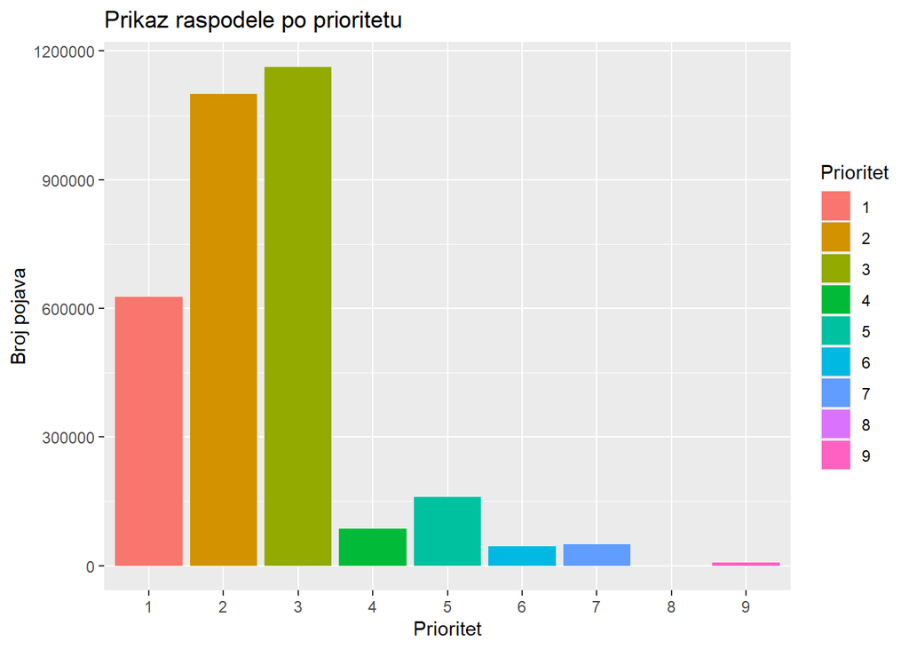

```r
priority_counts <- df_clean %>%
  group_by(Priority) %>%
  summarise(Count = n())

ggplot(priority_counts, aes(x = Priority, y = Count, fill = Priority)) +
  geom_bar(stat = "identity") +
  labs(title = "Prikaz raspodele po prioritetu",
       x = "Prioritet",
       y = "Broj pojava",
       fill = "Prioritet")
```

### Vizualizacija raspodele po načinu poziva 911 centra

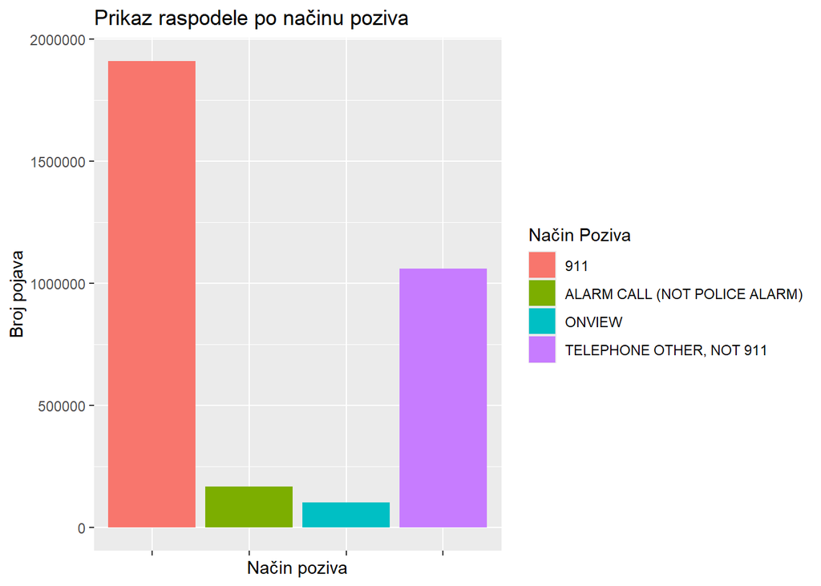

```r
call_type_counts <- df_clean %>%
  group_by(Call_Type) %>%
  summarise(Count = n())

call_type_counts <- call_type_counts %>% filter(Count > 5000)

ggplot(call_type_counts, aes(x = Call_Type, y = Count, fill = Call_Type)) +
  geom_bar(stat = "identity") +
  labs(title = "Prikaz raspodele po načinu poziva",
       x = "Način poziva",
       y = "Broj pojava",
       fill = "Način Poziva") +
  theme(axis.text.x = element_blank())
```

### Vizualizacija raspodele geografske širine i dužine

- Pravljenjem histograma za lokacijske podatke, može se primetiti da postoji određeni broj događaja koji imaju pogrešno specificiranu geografsku širinu ili dužinu. Naredni isečak koda prikazuje raspodele vrednosti geografske širine i dužine, kao i sređivanje tih vrednosti kako bi odgovarale koordinatama grada Sijetla.

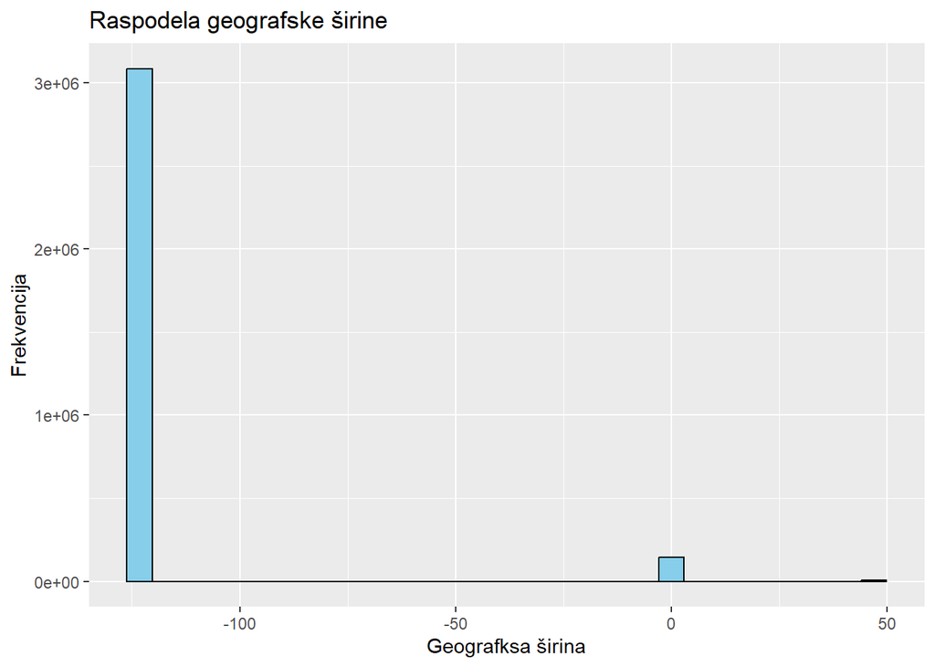

```r
ggplot(data = df_clean, aes(x = Blurred_Longitude)) +
  geom_histogram(bins = 30, fill = "skyblue", color = "black") +
  labs(title = "Raspodela geografske širine",
       x = "Geografksa širina",
       y = "Frekvencija")
```

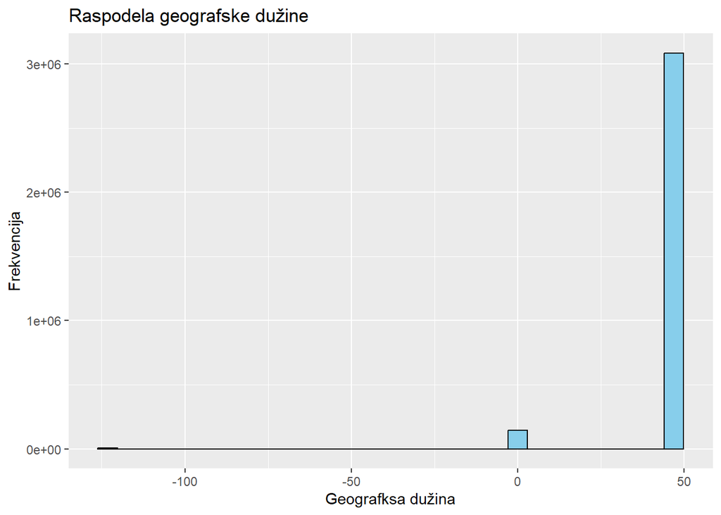

```r
ggplot(data = df_clean, aes(x = Blurred_Latitude)) +
  geom_histogram(bins = 30, fill = "skyblue", color = "black") +
  labs(title = "Raspodela geografske dužine",
       x = "Geografksa dužina",
       y = "Frekvencija")
```

- Može se primetiti na histogramima da postoji određeni broj entiteta koji imaju pogrešno unete koordinate geografske širine i dužine. S obzirom na to da ne postoji prevelik broj ovakvih entiteta, oni se mogu izbaciti iz skupa podataka. To se može uraditi na sledeći način:

```r
df_clean_ll <- df_clean %>% filter(Blurred_Latitude >= 47 & Blurred_Latitude <= 48 & Blurred_Longitude >= -123 & Blurred_Longitude <= -122)
```

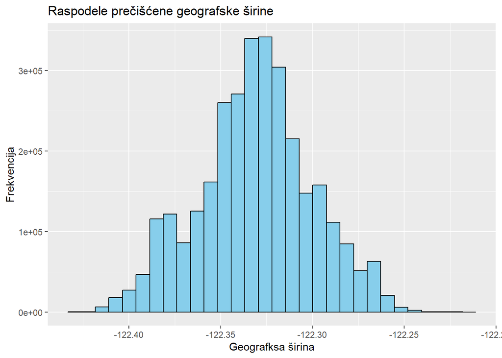

```r
ggplot(data = df_clean_ll, aes(x = Blurred_Longitude)) +
  geom_histogram(bins = 30, fill = "skyblue", color = "black") +
  labs(title = "Raspodele prečišćene geografske širine",
       x = "Geografksa širina",
       y = "Frekvencija")
```

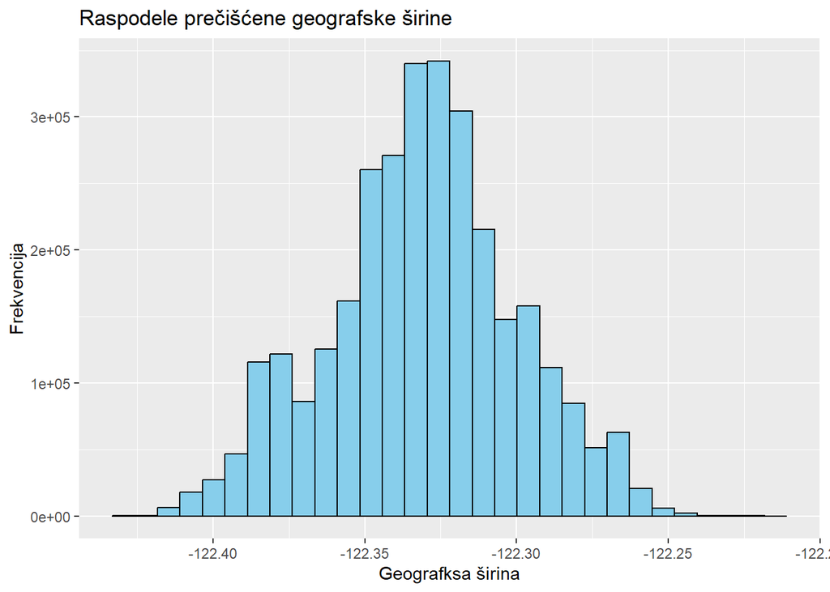

```r
ggplot(data = df_clean_ll, aes(x = Blurred_Longitude)) +
  geom_histogram(bins = 30, fill = "skyblue", color = "black") +
  labs(title = "Raspodele prečišćene geografske širine",
       x = "Geografksa širina",
       y = "Frekvencija")
```

- Raspodela ovih vrednosti se može prikazati i na mapi, uz upotrebu **ggmap** biblioteke i stadiamaps API kljuca, što prikazuje sledeći isečak koda:

```r
# Postavljanje vrednosti API kljuca
register_stadiamaps("04c1350e-f51f-4265-b458-ad6b6a3192bb", write = TRUE)
# Kreiranje mape Sijetla
seattle <- c(left = -122.45, bottom = 47.48, right = -122.2, top = 47.73)
seattle_map <- get_stadiamap(seattle, zoom = 18)
# Plotovanje mape
ggmap(seattle_map) +
 geom_point(data = df_clean_ll, aes(x = Blurred_Longitude, y = Blurred_Latitude,  color = Final_Call_Type))
 labs(title = "Mapa grada Sijetla",
      x = "Geografska širina",
      y = "Geografska širina",
 color = "Final Call Type")
```

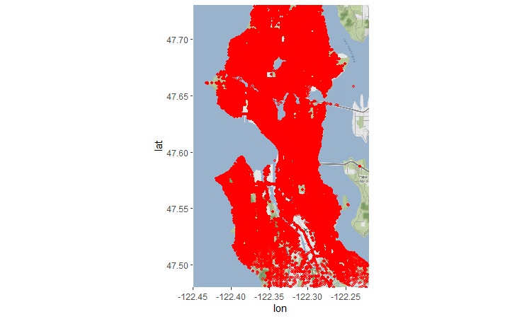

```r
include_graphics("Slike/PointsOnTheMap.png")
```

### Vizualizacija raspodele kategorija

```r
df_collected <- df_clean_ll %>% collect()
print(length(unique(df_collected$Initial_Call_Type)))
```

```
## [1] 287
```

```r
print(length(unique(df_collected$Final_Call_Type)))
```

```
## [1] 402
```

- Sledeći isečak koda prikazuje grupisanje inicijalnih kategorija poziva u natkategorije:

```r
df_clean_ll <- df_clean_ll %>%
  mutate(Initial_Category = case_when(
    grepl("ASLT|Assault|ASSAULT|ASSAULTS|HARRASMENT|THREAT|THREATS|WEAPON|GUN|PANHANDLING|HARASSMENT|VIOLENT", Initial_Call_Type) ~ "Assaults and Threats",
    grepl("TRAFFICING|SEX|RAPE|PORNOGRAPHY|PROSTITUTION|LEWD|PROWLER", Initial_Call_Type) ~ "Sex Offenses",
    grepl("NARCOTICS|DRUGS|MARIJUANA|OVERDOSE|OD|LIQUOR|DETOX|INTOX|LIQ", Initial_Call_Type) ~ "Narcotics",
    grepl("HARBOR|ANIMAL|GAMBLING|WATER|TREES|NORAD|STADIUM|ILLEGAL DUMPING|SLEEPER|HAZ|BIAS|NUISANCE|URINATING|HOSPITAL|PHONE|CROWD|EVENT|DEMONSTRATIONS|DISTURBANCE|UNUSUAL|NOISE|POWER|LANDLINE|LITTERING", Initial_Call_Type) ~ "Civil incidents and security",
    grepl("DOA|SHOTS|CASUALTY|FELONY|SUSPICIOUS|ESCAPE|FIRE|PURSUIT|SWAT|SHOOTING|SUICIDE|HOSTAGE|HOMICIDE", Initial_Call_Type) ~ "Emergency and Critical incidents",
    grepl("ROBBERY|BURGLARY|PROPERTY|THEFT|BREAKING|SHOPLIFT|ARSON|TRESPASS|BURG|BURN|EXPLOSION|FRAUD", Initial_Call_Type) ~ "Property Crimes",
    grepl("ALARM|ORDER|INSPECTION|WATCH", Initial_Call_Type) ~ "Alarm and Security",
    grepl("ASSIST|CHECK|HELP|ASSIGNED|PATROL", Initial_Call_Type) ~ "Assistance and Checks",
    grepl("DOMESTIC|ABUSE|CUSTODIAL|ARGUMENTS|DV", Initial_Call_Type) ~ "Domestic Violence",
    grepl("Traffic|VIOLATIONS|ACCIDENT|MVC|CAR|DUI|TRAF|ROAD|VEHICLE|DUI|ACC|HIT AND RUN|", Initial_Call_Type) ~ "Traffic Incident",
    grepl("MISSING|AWOL|FOUND|RUNAWAY|ABDUCTION|KIDNAP|CHILD|JUVENILE|LOST|AMBER|A.W.O.L.", Initial_Call_Type) ~ "Missing Persons",
    grepl("OBS", Initial_Call_Type) ~ "Observation",
    grepl("CANCELLED|NO ANSWER|OUT AT RANGE", Initial_Call_Type) ~ "No action",
    TRUE ~ "Other"
  ))
```

- Primena i na finalnu kategoriju poziva:

```r
df_clean_ll <- df_clean_ll %>%
  mutate(Final_Category = case_when(
    grepl("ASLT|Assault|ASSAULT|ASSAULTS|HARRASMENT|THREAT|THREATS|WEAPON|GUN|PANHANDLING|HARASSMENT|VIOLENT", Final_Call_Type) ~ "Assaults and Threats",
    grepl("TRAFFICING|SEX|RAPE|PORNOGRAPHY|PROSTITUTION|LEWD|PROWLER", Final_Call_Type) ~ "Sex Offenses",
    grepl("NARCOTICS|DRUGS|MARIJUANA|OVERDOSE|OD|LIQUOR|DETOX|INTOX|LIQ", Final_Call_Type) ~ "Narcotics",
    grepl("HARBOR|ANIMAL|GAMBLING|WATER|TREES|NORAD|STADIUM|ILLEGAL DUMPING|SLEEPER|HAZ|BIAS|NUISANCE|URINATING|HOSPITAL|PHONE|CROWD|EVENT|DEMONSTRATIONS|DISTURBANCE|UNUSUAL|NOISE|POWER|LANDLINE|LITTERING", Final_Call_Type) ~ "Civil incidents and security",
    grepl("DOA|SHOTS|CASUALTY|FELONY|SUSPICIOUS|ESCAPE|FIRE|PURSUIT|SWAT|SHOOTING|SUICIDE|HOSTAGE|HOMICIDE", Final_Call_Type) ~ "Emergency and Critical incidents",
    grepl("ROBBERY|BURGLARY|PROPERTY|THEFT|BREAKING|SHOPLIFT|ARSON|TRESPASS|BURG|BURN|EXPLOSION|FRAUD", Final_Call_Type) ~ "Property Crimes",
    grepl("ALARM|ORDER|INSPECTION|WATCH", Final_Call_Type) ~ "Alarm and Security",
    grepl("ASSIST|CHECK|HELP|ASSIGNED|PATROL", Final_Call_Type) ~ "Assistance and Checks",
    grepl("DOMESTIC|ABUSE|CUSTODIAL|ARGUMENTS|DV", Final_Call_Type) ~ "Domestic Violence",
    grepl("Traffic|VIOLATIONS|ACCIDENT|MVC|CAR|DUI|TRAF|ROAD|VEHICLE|DUI|ACC|HIT AND RUN|", Final_Call_Type) ~ "Traffic Incident",
    grepl("MISSING|AWOL|FOUND|RUNAWAY|ABDUCTION|KIDNAP|CHILD|JUVENILE|LOST|AMBER|A.W.O.L.", Final_Call_Type) ~ "Missing Persons",
    grepl("OBS", Final_Call_Type) ~ "Observation",
    grepl("CANCELLED|NO ANSWER|OUT AT RANGE", Final_Call_Type) ~ "No action",
    TRUE ~ "Other"
  ))
```

- S obzirom na to da je moguće da se desi da inicijalna kategorizacija od strane 911 operatera ne odgovara finalnoj kategorizaciji događaja od strane policajca, sledeći dijagram prikazuje raspodelu slučajeva kada je finalna kategorizacija odgovarala incijalnoj i obrnuto:

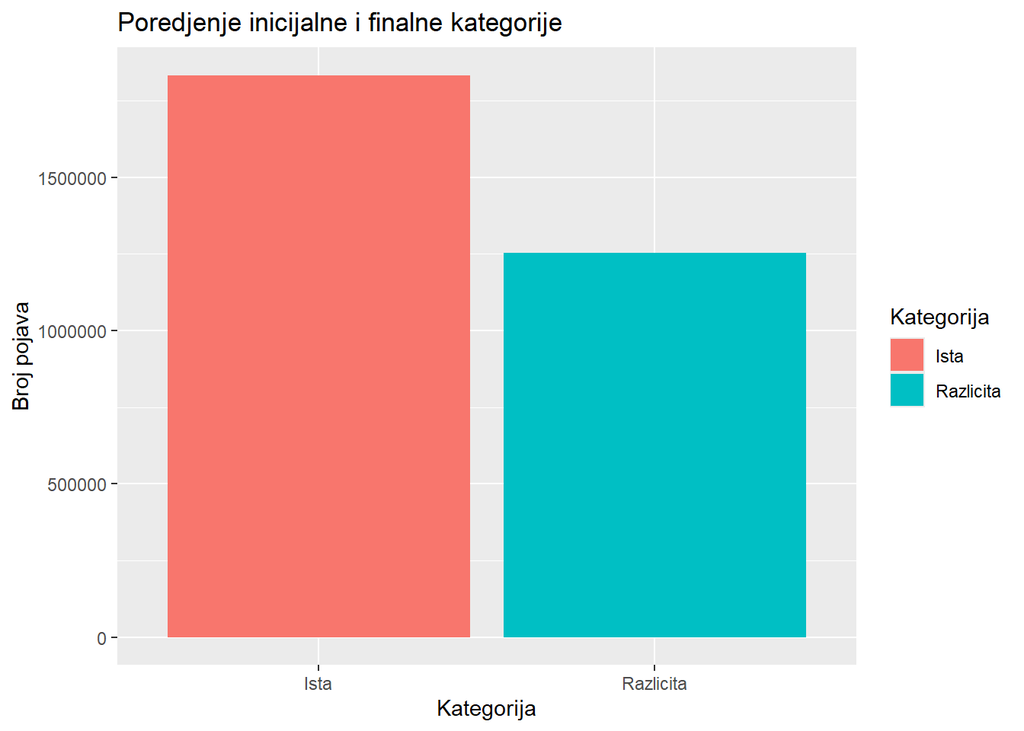

```r
same_diff_counts <- df_clean_ll %>%
  group_by(Same_Category = ifelse(Initial_Category == Final_Category, "Ista", "Razlicita")) %>%
  summarise(Count = n())

# Stubicasti dijagram za prikaz vrednosti
ggplot(same_diff_counts, aes(x = Same_Category, y = Count, fill = Same_Category)) +
  geom_bar(stat = "identity") +
  labs(title = "Poredjenje inicijalne i finalne kategorije",
       x = "Kategorija",
       y = "Broj pojava",
       fill = "Kategorija")
```

##### Raspodela inicijalnih kategorija

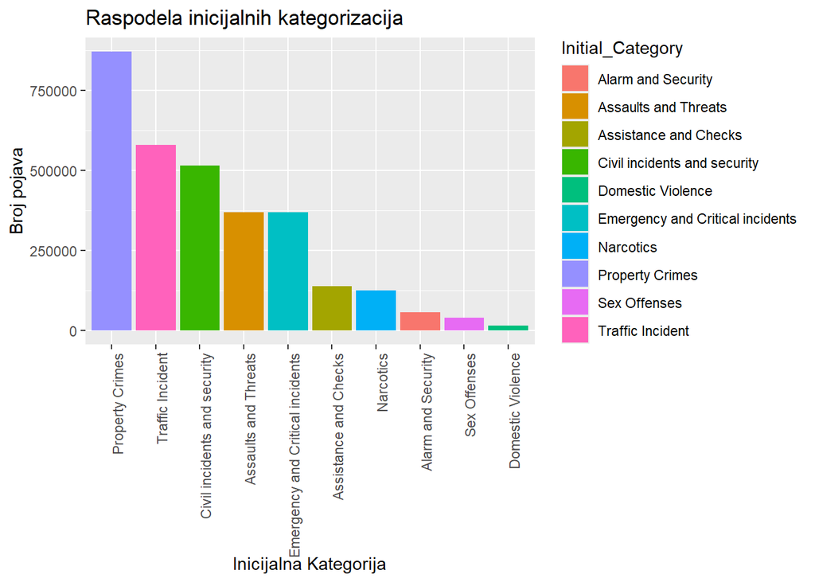

```r
initial_category_counts <- df_clean_ll %>%
  group_by(Initial_Category) %>%
  summarise(Count = n())

ggplot(initial_category_counts, aes(x = reorder(Initial_Category, -Count), y = Count, fill = Initial_Category)) +
  geom_bar(stat = "identity") +
  labs(title = "Raspodela inicijalnih kategorizacija",
       x = "Inicijalna Kategorija",
       y = "Broj pojava") +
  theme(axis.text.x = element_text(angle = 90, hjust = 1))
```

##### Raspodela finalnih kategorija

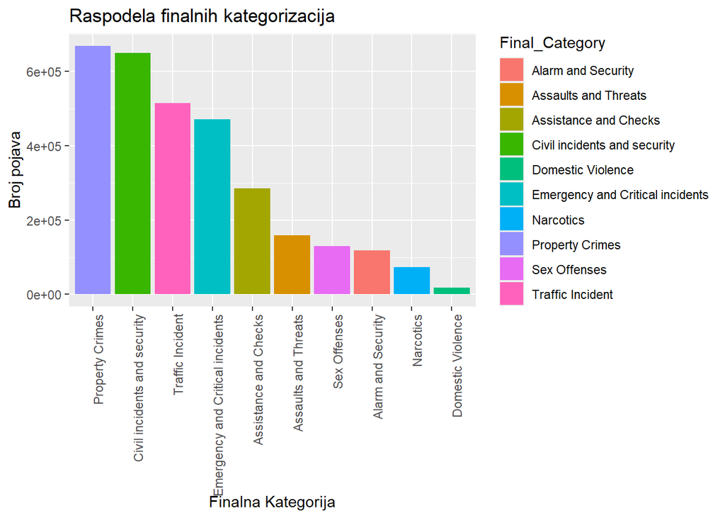

```r
final_category_counts <- df_clean_ll %>%
  group_by(Final_Category) %>%
  summarise(Count = n())

ggplot(final_category_counts, aes(x = reorder(Final_Category, -Count), y = Count, fill = Final_Category)) +
  geom_bar(stat = "identity") +
  labs(title = "Raspodela finalnih kategorizacija",
       x = "Finalna Kategorija",
       y = "Broj pojava") +
  theme(axis.text.x = element_text(angle = 90, hjust = 1))
```

##### Vizualizacija finalne kategorije prijave spram geografske sirine i duzine

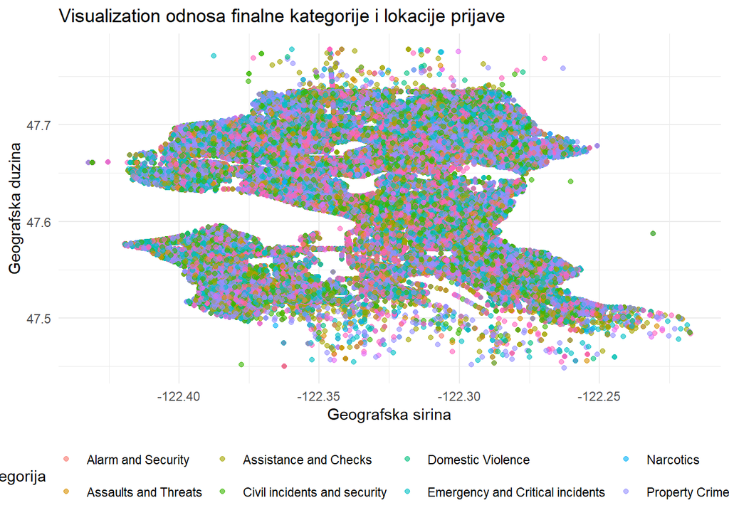

```r
ggplot(df_clean_ll, aes(x = Blurred_Longitude, y = Blurred_Latitude, color = Final_Category)) +
  geom_point(alpha = 0.6) +
  labs(title = "Visualization odnosa finalne kategorije i lokacije prijave",
       x = "Geografska sirina",
       y = "Geografska duzina",
       color = "Finalna kategorija") +
  theme_minimal() +
  theme(legend.position = "bottom")
```

- Na dijagramu iznad se moze videti da raspodela kategorija prekrsaja i zlocina ne zavisi od geografske sirine i duzine, stoga nema preteranog smisla pokusavati vrsiti klasterizaciju nad ovim vrednostima.

### Vizualizacija odnosa sektora i lokacije prijave:

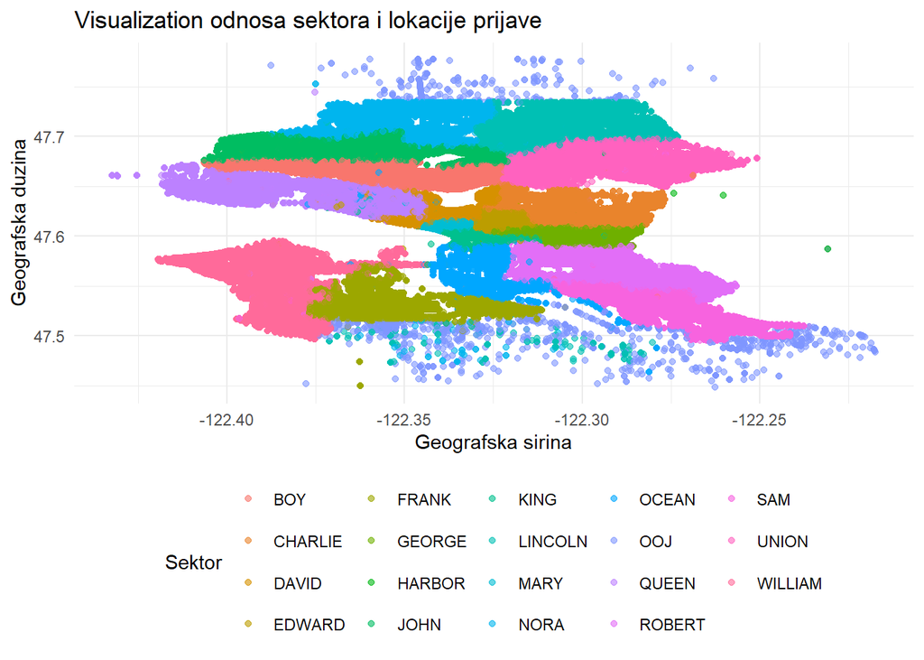

```r
ggplot(df_clean_ll, aes(x = Blurred_Longitude, y = Blurred_Latitude, color = Sector)) +
  geom_point(alpha = 0.6) +
  labs(title = "Visualization odnosa sektora i lokacije prijave",
       x = "Geografska sirina",
       y = "Geografska duzina",
       color = "Sektor") +
  theme_minimal() +
  theme(legend.position = "bottom")
```

### Vizualizacija odnosa policijske uprave i lokacije prijave

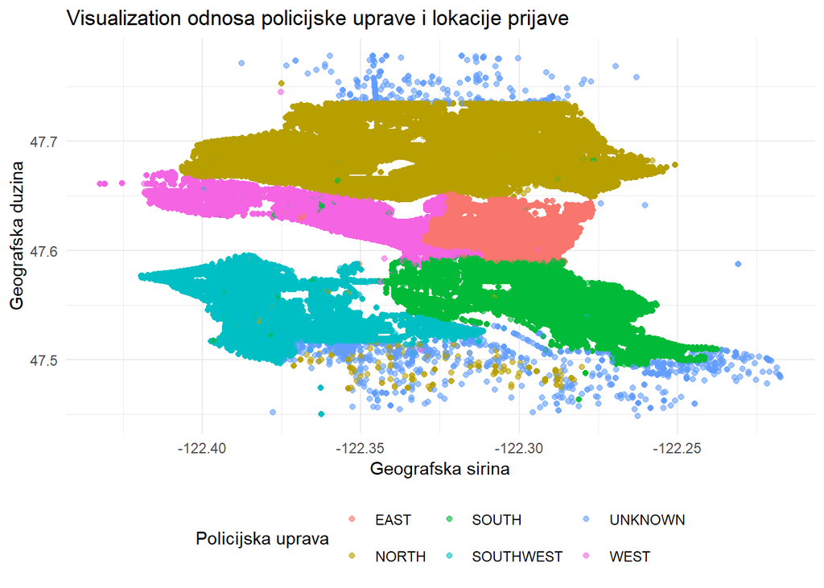

```r
ggplot(df_clean_ll, aes(x = Blurred_Longitude, y = Blurred_Latitude, color = Precinct)) +
  geom_point(alpha = 0.6) +
  labs(title = "Visualization odnosa policijske uprave i lokacije prijave",
       x = "Geografska sirina",
       y = "Geografska duzina",
       color = "Policijska uprava") +
  theme_minimal() +
  theme(legend.position = "bottom")
```

- Sa druge strane, može se uvideti da su odgovarajuće policijske uprave odgovorne za reakcije na odredjenim teritorijama grada, što ga ovaj skup podataka cini pogodnim za klasterizaciju spram geografske lokacije.

# Priprema podataka za klasfikaciju

### Računanje vremena odziva na događaj:

```r
df_times <- df_clean_ll %>%
  mutate(
    Response_Time = (unix_timestamp(Arrived_Time) - unix_timestamp(Original_Time_Queued)) / 60
  )
```

### Prikaz histograma kako bi se uvidela raspodela vremena odziva:

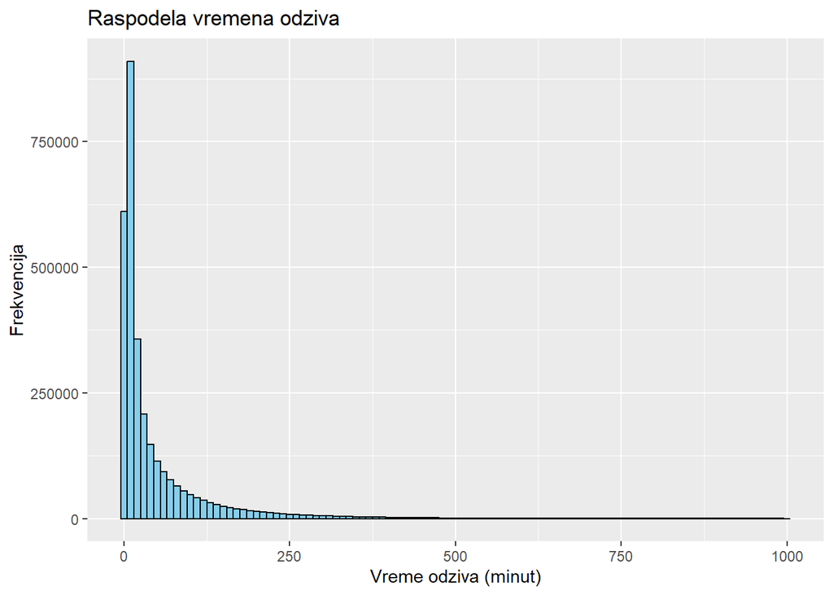

```r
# Plot histogram with 5-minute bins
df_times <- df_times %>% filter(Response_Time >= 0 & Response_Time <= 1000)

ggplot(df_times, aes(x = Response_Time)) +
  geom_histogram(binwidth = 10, fill = "skyblue", color = "black") +
  labs(title = "Raspodela vremena odziva",
       x = "Vreme odziva (minut)",
       y = "Frekvencija")
```

- Kako bi se izvršila binarna klasifikacija, kreirano je novo obeležje (labela) `Response_Speed` koje ima vrednosti 1 i 0. Vrednosti ovog obeležja se dodeljuju na osnovu medijalne vrednosti vremena odziva - `Response_Time`. Sve pojave koje imaju vreme odziva manje od medijalne ce imati vrednost labele `Response_Speed` - 1, što reprezentuje brz odziv, dok će ostale pojave imati vrednost - 0, odnosno spor odziv. Sledeći kod prikazuje kreiranje ovog obeležja u skupu podataka:

### Kreiranje labele brzine odziva

```r
dft <- df_times %>% collect()
median_value <- median(dft$Response_Time)
df_prepared <- df_times %>%
  mutate(Response_Speed = if_else(Response_Time <= median_value, 1, 0))
```

### Prikaz raspodele brzine odziva

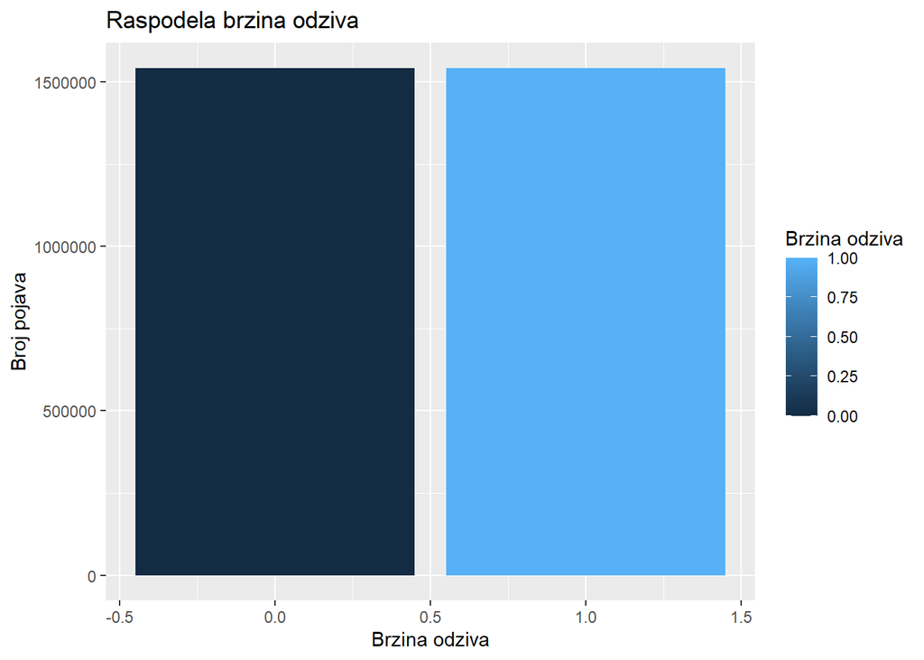

```r
response_speeds <- df_prepared %>%
  group_by(Response_Speed) %>%
  summarise(Count = n())

ggplot(response_speeds, aes(x = Response_Speed, y = Count, fill = Response_Speed)) +
  geom_bar(stat = "identity") +
  labs(title = "Raspodela brzina odziva",
       x = "Brzina odziva",
       y = "Broj pojava",
       fill = "Brzina odziva")
```

### Vizualizacija odnosa izmedju prediktorskih obeležja i ciljnog obeležja:

- Naredna sekcija ima za cilj da prikaže kako različite vrednosti prediktorskih obeležja utiču na brzinu odziva policijske jedinice na poziv. Naredni isecak koda ima za cilj da prikaze kako prioritet, inicijalna kategorija poziva, lokacija i sektor uticu na vremena odziva.

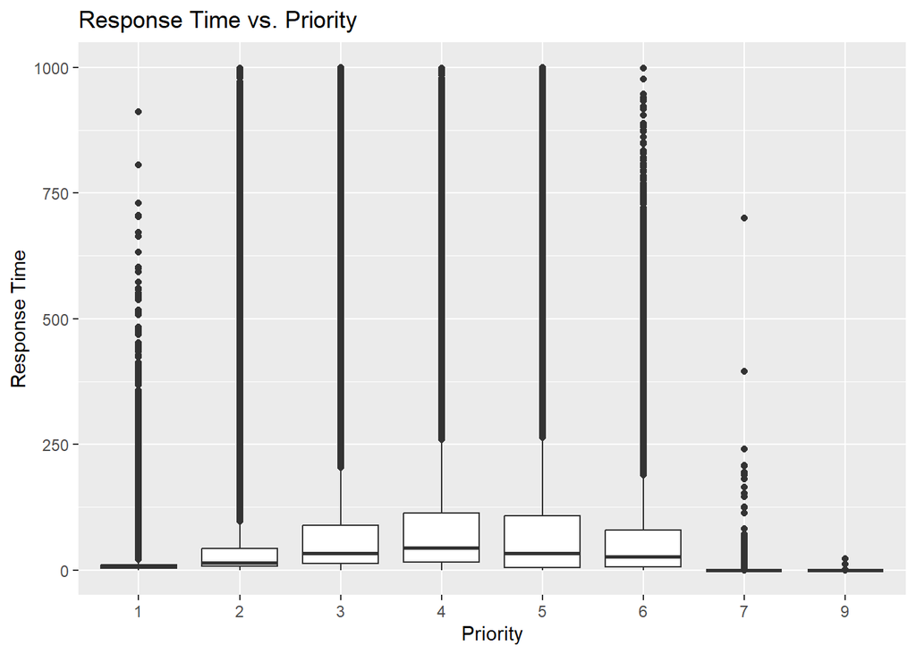

```r
ggplot(df_prepared, aes(x = Priority, y = Response_Time)) +
  geom_boxplot() +
  labs(title = "Response Time vs. Priority", x = "Priority", y = "Response Time")
```

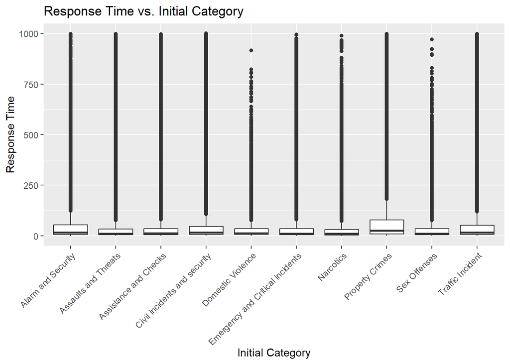

```r
ggplot(df_prepared, aes(x = Initial_Category, y = Response_Time)) +
  geom_boxplot() +
  labs(title = "Response Time vs. Initial Category", x = "Initial Category", y = "Response Time") +
  theme(axis.text.x = element_text(angle = 45, hjust = 1))
```

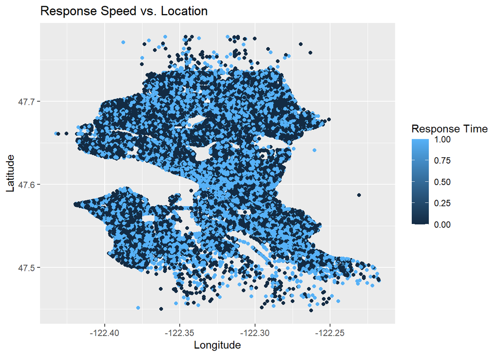

```r
ggplot(df_prepared, aes(x = Blurred_Longitude, y = Blurred_Latitude, color = Response_Speed)) +
  geom_point() +
  labs(title = "Response Speed vs. Location", x = "Longitude", y = "Latitude", color = "Response Time")
```

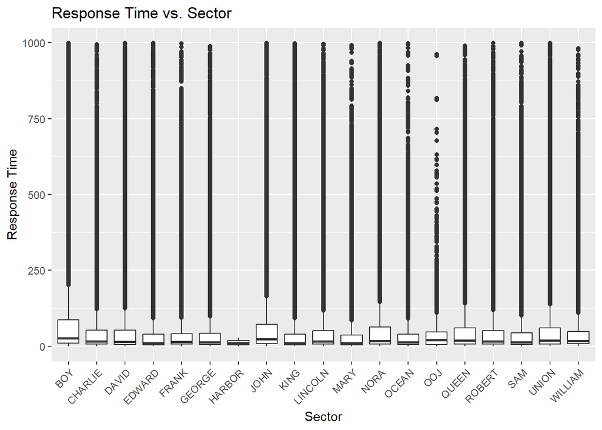

```r
ggplot(df_prepared, aes(x = Sector, y = Response_Time)) +
  geom_boxplot() +
  labs(title = "Response Time vs. Sector", x = "Sector", y = "Response Time") +
  theme(axis.text.x = element_text(angle = 45, hjust = 1))
```

- Može se primetiti da se za događaje koji su visokog prioriteta dešava brza reakcija policije, što je i očekivano.
- Takođe, i za određene inicijalne kategorije, kao što su `Domestic Violence` i `Emergency and Critical Incidents` dešava brza reakcija.
- Sa druge strane, korelacija između brzine odziva i geografske lokacije, nije previše očigledna, s obzirom na to da postoji uniformna raspodela brzina odziva u odnosu na geografsku lokaciju.

# Klasifikacija

### Priprema skupa podataka za obucavanje

- S obzirom na to da je cilj klasifikacije da se utvrdi brzina odgovora policijske jedinice, kao prediktorska obeležja su izabrani: `Response_Time`, `Sector`, `Precinct`, `Initial_Category`, `Longitude` i `Latitude`
- Naredni isečak koda prikazuje podelu skupa podataka na trening i validacioni set:

```r
df_prepared_split <- df_prepared %>%
  select(Response_Time, Response_Speed, Sector, Precinct, Initial_Category, Blurred_Longitude, Blurred_Latitude, Priority) %>%
  sdf_random_split(training = 0.8,
                   test = 0.2,
                   seed = 100)
```

### Logistička regresija

- Za potrebe evaluacije modela logističke regresije i izbora najpovoljnijeg modela, kreirana su tri scenarija sa različitim vrednostima regularizacionog parametra lambda.
- Za evaluaciju modela je korišćena areaUnderROC metrika koja reprezentuje sposobnost klasifikacionog modela da razvrsta dve klase.

##### Priprema modela, scenarija i treniranje

```r
# Logistic Regression
log_pipeline <- sc %>%
  ml_pipeline() %>%
  ft_r_formula(Response_Speed ~ .) %>%
  ml_logistic_regression()

param_grid <- list(
  logistic_regression = list(reg_param = c(0.01, 0.1, 1))
)

lr_evaluator <- ml_binary_classification_evaluator(x = sc, metricName = "areaUnderROC")

# Kros-validacija
logistic_cv <- ml_cross_validator(
  x = sc,
  estimator = log_pipeline,
  estimator_param_maps = param_grid,
  evaluator = lr_evaluator,
  num_folds = 5
)

print(logistic_cv)
```

```
## CrossValidator (Estimator)
## <cross_validator__fd48109b_bc0e_4fdd_bfa5_65966d1bdec3>
##  (Parameters -- Tuning)
##   estimator: Pipeline
##              <pipeline__f4dda3a8_46a9_4c88_9c1b_e341f0bf7a41>
##   evaluator: BinaryClassificationEvaluator
##              <binary_classification_evaluator__a8a9faec_20b3_46aa_9c53_295832636abd>
##     with metric areaUnderROC
##   num_folds: 5
##   [Tuned over 3 hyperparameter sets]
```

```r
model_cv <- ml_fit(
  x = logistic_cv,
  dataset = df_prepared_split$training
)

cv_metrics <- ml_validation_metrics(model_cv)

print(cv_metrics)
```

```
##   areaUnderROC reg_param_1
## 1    0.9632941        0.01
## 2    0.9026665        0.10
## 3    0.8514392        1.00
```

##### Prikaz performansi modela logističke regresije za različite scenarije

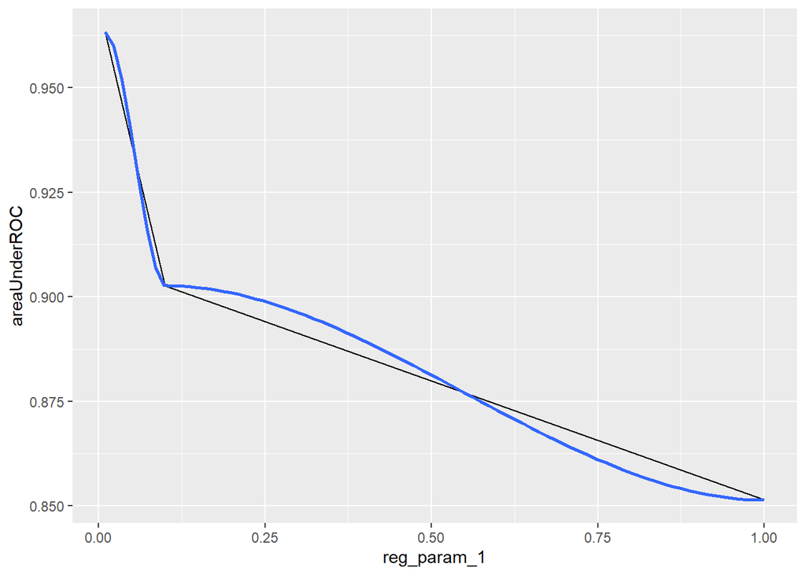

```r
cv_metrics %>%
  ggplot(aes(reg_param_1, areaUnderROC)) +
  geom_line() +
  geom_smooth()
```

- Analiziranjem dijagrama se može utvrditi da se najbolje performanse dobijaju za vrednost 0.01 regularizacionog parametra.

##### Izbor najpovoljnijeg modela

```r
# Na osnovu grafa se utvrdjuje da je model sa parametrom regularizacije 0.01 najbolji
lmodel <- ml_logistic_regression(
  df_prepared_split$training,
  Response_Speed ~ .,
  reg_param = 0.01
)

lrmx <- lmodel %>%
  ml_predict(df_prepared_split$test) %>%
  ml_metrics_binary()
```

### Random Forest algoritam

- Za potrebe evaluacije random forest modela i izbora najpovoljnijeg, kreirana su tri scenarija sa različitim brojem stabala.
- Za evaluaciju modela je korišćena areaUnderROC metrika koja reprezentuje sposobnost klasifikacionog modela da razvrsta dve klase.

##### Priprema random forest modela

```r
# Random Forest
rf_pipeline <- sc %>%
  ml_pipeline() %>%
  ft_r_formula(Response_Speed ~ .) %>%
  ml_random_forest_classifier()

rf_grid <- list(
  random_forest_classifier = list(
    num_trees = c(3, 25, 50)
  )
)

rf_evaluator = ml_binary_classification_evaluator(x = sc, metricName = "areaUnderROC")

# Kros-validacija
rf_cv <- ml_cross_validator(
  x = sc,
  estimator = rf_pipeline,
  estimator_param_maps = rf_grid,
  evaluator = rf_evaluator,
  num_folds = 5
)

model_rf_cv <- ml_fit(
  x = rf_cv,
  dataset = df_prepared_split$training
)

rf_cv_metrics <- ml_validation_metrics(model_rf_cv)

print(rf_cv_metrics)
```

```
##   areaUnderROC num_trees_1
## 1    0.9658566           3
## 2    0.9984843          25
## 3    0.9984970          50
```

##### Prikaz performansi random forest modela za različite scenarije

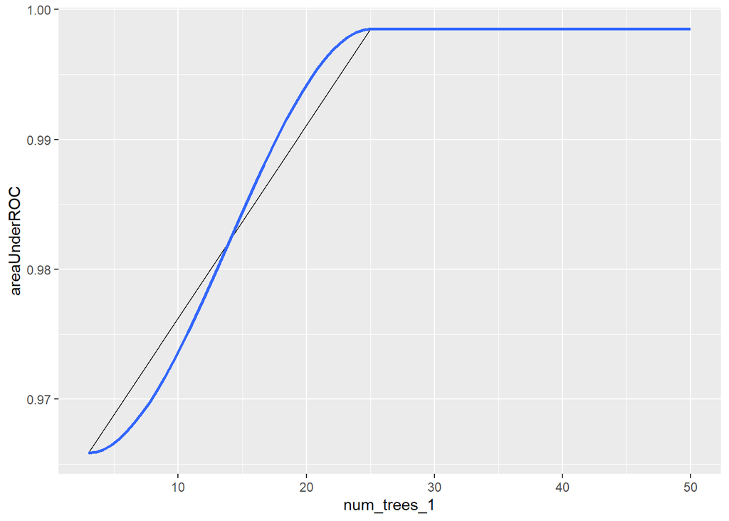

```r
rf_cv_metrics %>%
  ggplot(aes(num_trees_1, areaUnderROC)) +
  geom_line() +
  geom_smooth()
```

- Može se primetiti da se performanse poboljšavaju za veći broj stabala.

##### Izbor najpovoljnijeg modela

```r
# Izbor najboljeg modela

rfmodel <- ml_random_forest_classifier(
  df_prepared_split$training,
  Response_Speed ~ .,
  num_trees = 50
)

rfmx <- rfmodel %>%
  ml_predict(df_prepared_split$test) %>%
  ml_metrics_binary()
```

### Stabla odlučivanja

- Za potrebe evaluacije modela stabla odlučivanja i izbora najpovoljnijeg, kreirana su tri scenarija sa različitom dubinom stabala.
- Za evaluaciju modela je korišćena areaUnderROC metrika koja reprezentuje sposobnost klasifikacionog modela da razvrsta dve klase.

```r
dt_pipeline <- sc %>%
  ml_pipeline() %>%
  ft_r_formula(Response_Speed ~ .) %>%
  ml_decision_tree_classifier()

dt_grid <- list(
  decision_tree_classifier = list(
    max_depth = c(3, 5, 10)
  )
)

dt_evaluator <- ml_binary_classification_evaluator(x = sc, metricName = "areaUnderROC")

# Kros-validacija
dt_cv <- ml_cross_validator(
  x = sc,
  estimator = dt_pipeline,
  estimator_param_maps = dt_grid,
  evaluator = dt_evaluator,
  num_folds = 5
)

model_dt_cv <- ml_fit(
  x = dt_cv,
  dataset = df_prepared_split$training
)

dt_cv_metrics <- ml_validation_metrics(model_dt_cv)

print(dt_cv_metrics)
```

```
##   areaUnderROC max_depth_1
## 1    0.9937336           3
## 2    0.9937336           5
## 3    0.9996537          10
```

##### Prikaz performansi modela stabla odlučivanja za različite scenarije

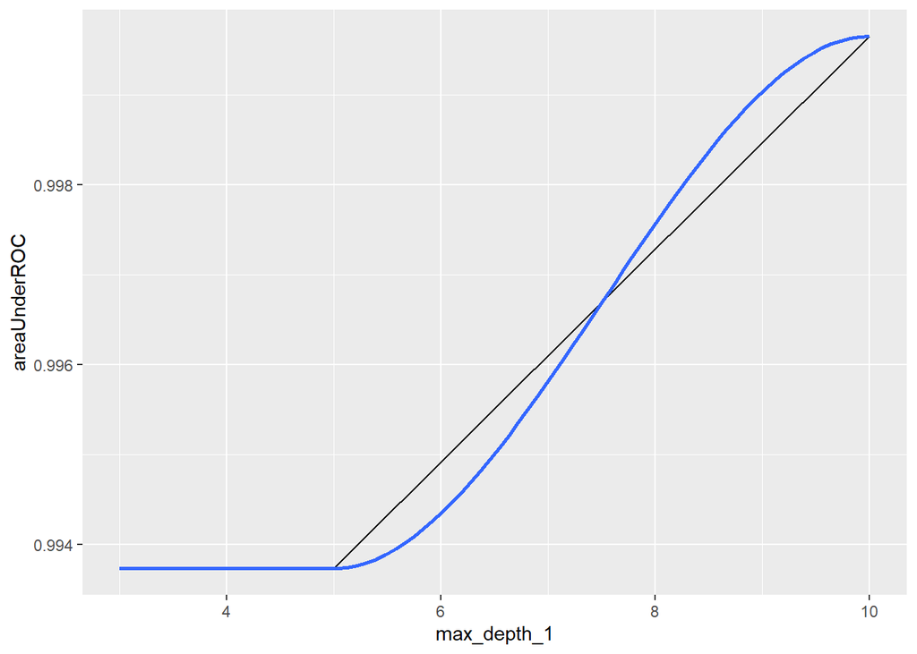

```r
dt_cv_metrics %>%
  ggplot(aes(max_depth_1, areaUnderROC)) +
  geom_line() +
  geom_smooth()
```

- Može se primetiti da sa povećanjem dubine stabla se povećavaju i performanse modela.
- Ipak treba uzeti u obzir da se sa povećanjem dubine stabla povećava i rizik da se model pretrenira.

##### Izbor najpovoljnijeg modela

```r
# Izbor najpovoljnijeg modela

dtmodel <- ml_decision_tree_classifier(
  df_prepared_split$training,
  Response_Speed ~ .,
  max_depth = 5
)

dtmx <- dtmodel %>%
  ml_predict(df_prepared_split$test) %>%
  ml_metrics_binary()
```

### Ocenjivanje performansi klasifikacije razlicitih metoda:

- Kako bi se ocenile performanse različitih modela, korišćene su areaUnderROC i areaUnderPR metrike

```r
metrics_df <- data.frame(
  model = c("Logistic Regression", "Random Forest", "Decision Tree"),
  auc_roc = NA,
  pr_auc = NA
)

# Fill in the metrics for each model
metrics_df[1, "auc_roc"] <- lrmx$.estimate[1]
metrics_df[1, "pr_auc"] <- lrmx$.estimate[2]

metrics_df[2, "auc_roc"] <- rfmx$.estimate[1]
metrics_df[2, "pr_auc"] <- rfmx$.estimate[2]

metrics_df[3, "auc_roc"] <- dtmx$.estimate[1]
metrics_df[3, "pr_auc"] <- dtmx$.estimate[2]

print(metrics_df)
```

```
##                 model   auc_roc    pr_auc
## 1 Logistic Regression 0.9635318 0.9540125
## 2       Random Forest 0.9984689 0.9990408
## 3       Decision Tree 0.9936368 0.9968177
```

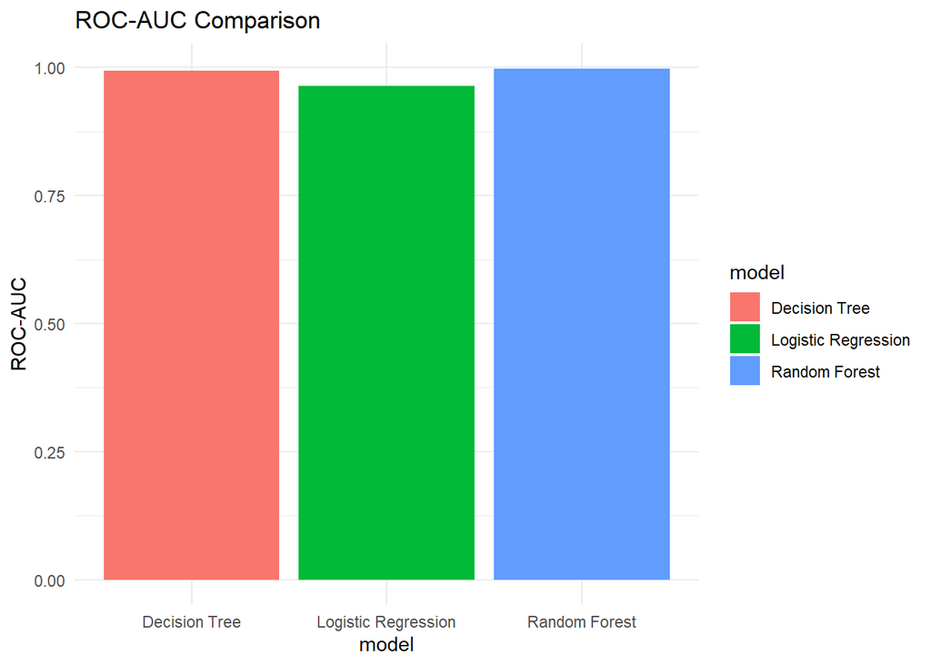

```r
ggplot(metrics_df, aes(x = model, y = auc_roc, fill = model)) +
  geom_bar(stat = "identity", position = "dodge") +
  labs(title = "ROC-AUC Comparison", y = "ROC-AUC") +
  theme_minimal()
```

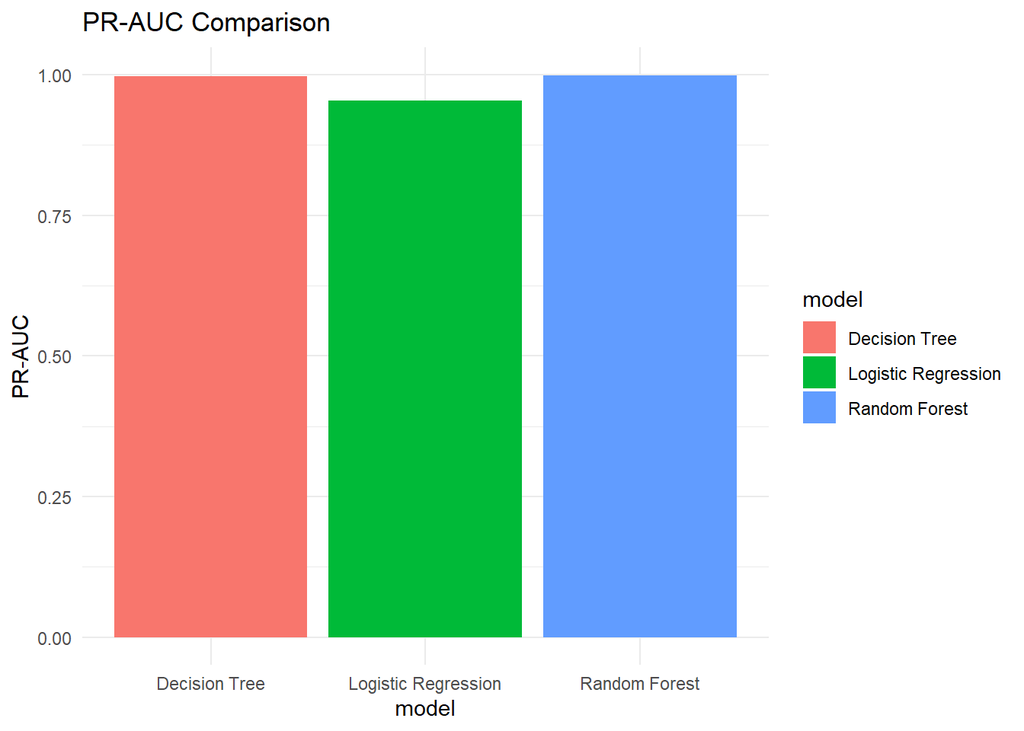

```r
ggplot(metrics_df, aes(x = model, y = pr_auc, fill = model)) +
  geom_bar(stat = "identity", position = "dodge") +
  labs(title = "PR-AUC Comparison", y = "PR-AUC") +
  theme_minimal()
```

- Dijagrami iznad prikazuju odnos ovih metrika između različitih modela
- Može se primetiti da najbolje performanse pruža random forest model

# Klasterizacija

- Ideja je da se klasterizacija vrši spram geografske širine i dužine kako bi se utvrdilo da li postoji određena korelacija između pojedinačnih obeležja i lokacije unutar grada Sijetla. Na primer, moglo bi se pokušati utvrditi da li postoji veza između tipa incidenta koji se dogodio i određenih delova grada Sijetla. Pored toga, može se utvrditi i veza između lokacije incidenta i policijske uprave koja je odgovorna za taj incident.
- Kako bi se izvršila klasterizacija, najpre je neophodno pripremiti skup podataka za algoritme.

### Priprema podataka za klasterizaciju

- U okviru pripreme skupa podataka izvdojeni su geografska širina i dužina, jer će se na osnovu njih, za početak, utvrđivati pogodan broj klastera.

```r
dataset.clustering <- df_times %>%
  select(Blurred_Longitude, Blurred_Latitude, Final_Category, Precinct)
```

### Ispitivanje pogodne veličine klastera primenom lakat metode

- Da bi se utvrdio najpovoljniji broj klastera, primenjena je lakat metoda (engl. *Elbow method*) koja prikazuje sumu kvadratne greške za specificirane brojeve klastera.

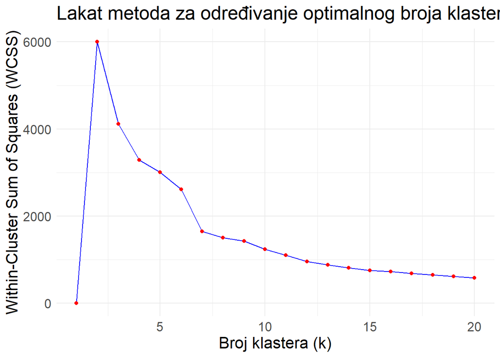

```r
# Funkcija koja racuna within-cluster-sum-of-squares

calculate_wcss <- function(data, max_k) {
  wcss <- numeric(max_k)

  for (kc in 2:max_k) {
    model <- ml_bisecting_kmeans(data, ~Blurred_Longitude + Blurred_Latitude, k = kc, max_iter = 10)
    wcss[kc] <- sum(model$cost)
  }

  return(wcss)
}

max_k <- 20
wcss_values <- calculate_wcss(dataset.clustering, max_k)

wcss_df <- data.frame(
  k = 1:max_k,
  WCSS = wcss_values
)

ggplot(wcss_df, aes(x = k, y = WCSS)) +
  geom_line(color = "blue") +
  geom_point(color = "red") +
  labs(title = "Lakat metoda za određivanje optimalnog broja klastera",
       x = "Broj klastera (k)",
       y = "Within-Cluster Sum of Squares (WCSS)") +
  theme_minimal() +
  theme(text = element_text(size = 16))
```

### Kreiranje klasterizacionih modela

```r
model.k7 <- ml_bisecting_kmeans(dataset.clustering, ~Blurred_Longitude + Blurred_Latitude, k = 7, seed = 1, max_iter = 10)
clusters.k7 <- ml_predict(model.k7, dataset.clustering)

model.k10 <- ml_bisecting_kmeans(dataset.clustering, ~Blurred_Longitude + Blurred_Latitude, k = 10, seed = 1, max_iter = 10)
clusters.k10 <- ml_predict(model.k10, dataset.clustering)
```

### Ispitivanje strukture klastera

- Pod ispitivanjem strukture klastera spada nekoliko parametara čije se vrednosti pokazuju, a to su:
  1. Centroida klastera
  2. Veličina i gustina klastera - Odnosi se na broj pojava unutar klastera i koliko su one “spakovane” unutar njega.
  3. Varijansa klastera (Raširenost) - Predstavlja disperziju vrednosti unutar klastera. Niska varijansa označava da su vrednosti unutar klastera smeštene oko centroide.
  4. Međuklasterska udaljenost - Predstavlja distancu između centroida dva klastera
  5. Unutarklasterska sličnost -> Označava koliko su vrednosti unutar klastera bliske jedna drugoj

##### Struktura klastera za k = 7

```r
variance_within_clusters <- function(data) {
  data %>%
    group_by(prediction) %>%
    summarise(across(c(Blurred_Longitude, Blurred_Latitude), var))
}

cluster_summary <- function(data) {
  data %>%
    group_by(prediction) %>%
    summarise(across(c(Blurred_Longitude, Blurred_Latitude), list(mean = mean, sd = sd, median = median)))
}

centers.k7 <- model.k7$centers
sizes.k7 <- table(dplyr::pull(clusters.k7, prediction))
variance.k7 <- variance_within_clusters(clusters.k7)
summary.k7 <- cluster_summary(clusters.k7)

print(centers.k7)
```

```
##   Blurred_Longitude Blurred_Latitude
## 1         -122.3640         47.54190
## 2         -122.2873         47.54403
## 3         -122.3448         47.60937
## 4         -122.3155         47.60708
## 5         -122.3657         47.66500
## 6         -122.3073         47.66864
## 7         -122.3269         47.71288
```

```r
print(sizes.k7)
```

```
##
##      0      1      2      3      4      5      6
## 300165 359805 644392 663615 446872 294830 375621
```

```r
print(variance.k7)
```

```
## # Source:   SQL [7 x 3]
## # Database: spark_connection
##   prediction Blurred_Longitude Blurred_Latitude
##        <int>             <dbl>            <dbl>
## 1          5          0.000268         0.000143
## 2          3          0.000133         0.000164
## 3          1          0.000355         0.000402
## 4          2          0.000283         0.000170
## 5          6          0.000454         0.000165
## 6          4          0.000385         0.000366
## 7          0          0.000370         0.000312
```

```r
print(summary.k7)
```

```
## # Source:   SQL [7 x 7]
## # Database: spark_connection
##   prediction Blurred_Longitude_mean Blurred_Longitude_sd Blurred_Longitude_med…¹
##        <int>                  <dbl>                <dbl>                   <dbl>
## 1          5                  -122.               0.0164                   -122.
## 2          3                  -122.               0.0115                   -122.
## 3          1                  -122.               0.0188                   -122.
## 4          2                  -122.               0.0168                   -122.
## 5          6                  -122.               0.0213                   -122.
## 6          4                  -122.               0.0196                   -122.
## 7          0                  -122.               0.0192                   -122.
## # ℹ abbreviated name: ¹Blurred_Longitude_median
## # ℹ 3 more variables: Blurred_Latitude_mean <dbl>, Blurred_Latitude_sd <dbl>,
## #   Blurred_Latitude_median <dbl>
```

##### Struktura klastera za k = 10

```r
centers.k10 <- model.k10$centers
sizes.k10 <- table(dplyr::pull(clusters.k10, prediction))
variance.k10 <- variance_within_clusters(clusters.k10)
summary.k10 <- cluster_summary(clusters.k10)

print(centers.k10)
```

```
##    Blurred_Longitude Blurred_Latitude
## 1          -122.3640         47.54190
## 2          -122.2873         47.54403
## 3          -122.3916         47.57920
## 4          -122.3403         47.61223
## 5          -122.3153         47.59591
## 6          -122.3158         47.61715
## 7          -122.3773         47.67457
## 8          -122.3491         47.65019
## 9          -122.3073         47.66864
## 10         -122.3269         47.71288
```

```r
print(sizes.k10)
```

```
##
##      0      1      2      3      4      5      6      7      8      9
## 300165 359805  55818 588574 314598 349017 265650 181222 294830 375621
```

```r
print(variance.k10)
```

```
## # Source:   SQL [10 x 3]
## # Database: spark_connection
##    prediction Blurred_Longitude Blurred_Latitude
##         <int>             <dbl>            <dbl>
##  1          5         0.000133         0.0000411
##  2          3         0.0000660        0.0000882
##  3          1         0.000355         0.000402
##  4          2         0.000169         0.0000387
##  5          6         0.000204         0.000284
##  6          9         0.000454         0.000165
##  7          7         0.000180         0.000130
##  8          4         0.000134         0.0000641
##  9          0         0.000370         0.000312
## 10          8         0.000268         0.000143
```

```r
print(summary.k10)
```

```
## # Source:   SQL [10 x 7]
## # Database: spark_connection
##    prediction Blurred_Longitude_mean Blurred_Longitude_sd Blurred_Longitude_me…¹
##         <int>                  <dbl>                <dbl>                  <dbl>
##  1          5                  -122.              0.0115                   -122.
##  2          3                  -122.              0.00812                  -122.
##  3          1                  -122.              0.0188                   -122.
##  4          2                  -122.              0.0130                   -122.
##  5          6                  -122.              0.0143                   -122.
##  6          9                  -122.              0.0213                   -122.
##  7          7                  -122.              0.0134                   -122.
##  8          4                  -122.              0.0116                   -122.
##  9          0                  -122.              0.0192                   -122.
## 10          8                  -122.              0.0164                   -122.
## # ℹ abbreviated name: ¹Blurred_Longitude_median
## # ℹ 3 more variables: Blurred_Latitude_mean <dbl>, Blurred_Latitude_sd <dbl>,
## #   Blurred_Latitude_median <dbl>
```

### Vizualizacija klastera

```r
plot_clusters <- function(data, centers, title) {
  ggplot(data, aes(x = Blurred_Longitude, y = Blurred_Latitude, color = as.factor(prediction))) +
    geom_point(size = 2) +
    geom_point(data = centers, aes(x = Blurred_Longitude, y = Blurred_Latitude), color = "black", size = 3, shape = 4) +
    labs(color = "Klaster", title = title, x = "Geografska dužina", y = "Geografska širina") +
    theme_minimal() +
    theme(text = element_text(size = 16))
}


sample_data.k7 <- clusters.k7 %>% sample_frac(0.01)
sample_data.k10 <- clusters.k10 %>% sample_frac(0.01)
heatmap3 <- plot_clusters(collect(sample_data.k7), centers.k7, "Density Heatmap for K=7")
heatmap4 <- plot_clusters(collect(sample_data.k10), centers.k10, "Density Heatmap for K=10")

ggsave("heatmap3.jpg", heatmap3)
ggsave("heatmap4.jpg", heatmap4)
```

### Prikazivanje odnosa izmedju vrednosti pojedinačnih obeležja i klastera

##### Veza izmedju Finalne kategorije incidenta i klastera za k = 7

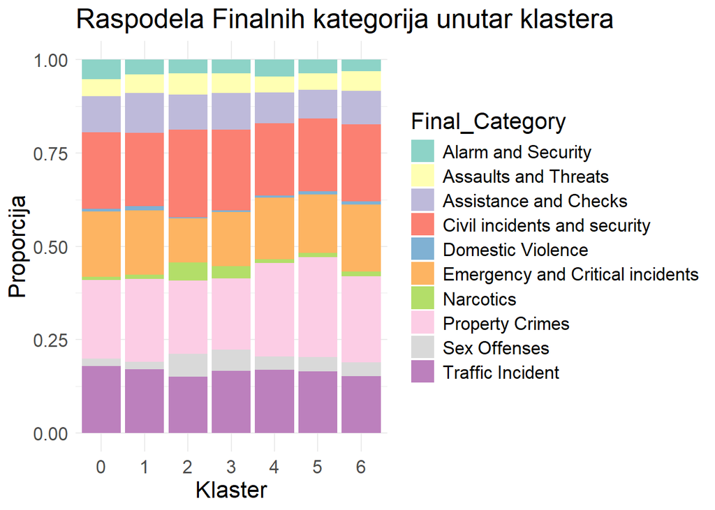

```r
ggplot(data = collect(sample_data.k7), aes(x = as.factor(prediction))) +
  geom_bar(aes(fill = Final_Category), position = "fill") +
  labs(x = "Klaster", y = "Proporcija", title = "Raspodela Finalnih kategorija unutar klastera") +
  scale_fill_brewer(palette = "Set3") +
  theme_minimal() +
  theme(text = element_text(size = 16))
```

- Može se primetiti da za različite delove grada Sijetla (predstavljene klasterima), dolazi do ravnomerne zastupljenosti incidenata.

##### Veza izmedju Policijske uprave i klastera za k = 7

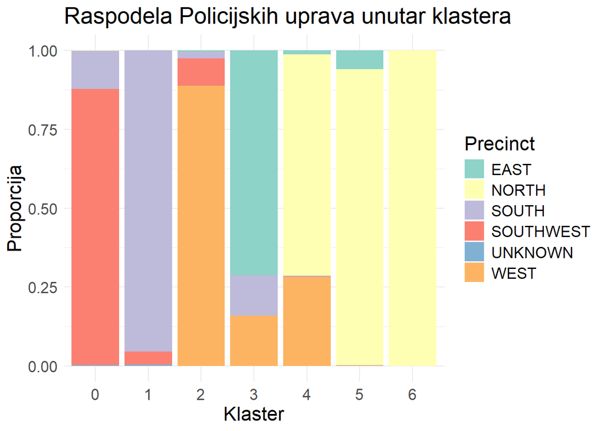

```r
# Precinct and Cluster
ggplot(data = collect(sample_data.k7), aes(x = as.factor(prediction))) +
  geom_bar(aes(fill = Precinct), position = "fill") +
  labs(x = "Klaster", y = "Proporcija", title = "Raspodela Policijskih uprava unutar klastera") +
  scale_fill_brewer(palette = "Set3") +
  theme_minimal() +
  theme(text = element_text(size = 16))
```

- Analizom ove raspodele može se utvrditi da za određene delove grada su zadužene određene policijske uprave, što je i logično.

##### Veza izmedju Finalne kategorije incidenta i klastera za k = 10

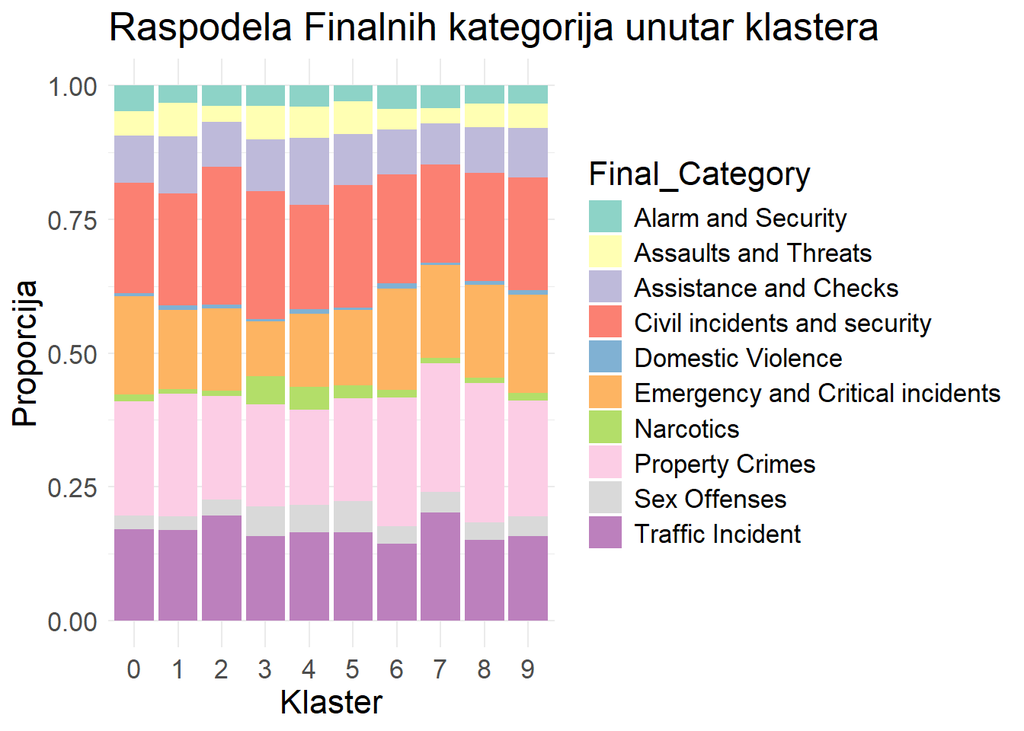

```r
ggplot(data = collect(sample_data.k10), aes(x = as.factor(prediction))) +
  geom_bar(aes(fill = Final_Category), position = "fill") +
  labs(x = "Klaster", y = "Proporcija", title = "Raspodela Finalnih kategorija unutar klastera") +
  scale_fill_brewer(palette = "Set3") +
  theme_minimal() +
  theme(text = element_text(size = 16))
```

- Primećuje se da ne postoji veza između određenih delova grada i inicidenata koji se dešavaju.

##### Veza izmedju Policijske uprave i klastera za k = 10

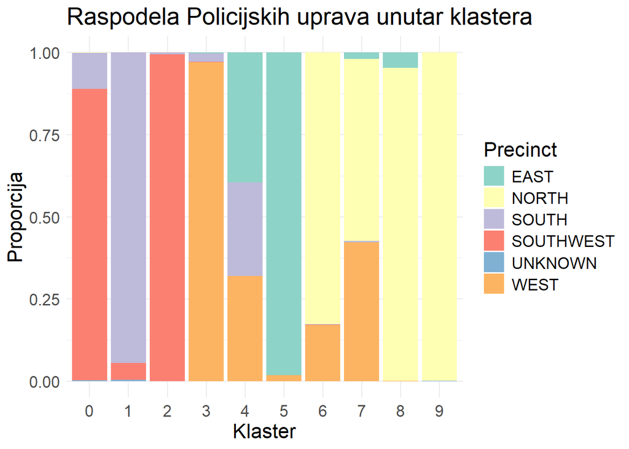

```r
# Precinct and Cluster
ggplot(data = collect(sample_data.k10), aes(x = as.factor(prediction))) +
  geom_bar(aes(fill = Precinct), position = "fill") +
  labs(x = "Klaster", y = "Proporcija", title = "Raspodela Policijskih uprava unutar klastera") +
  scale_fill_brewer(palette = "Set3") +
  theme_minimal() +
  theme(text = element_text(size = 16))
```